# Dealing With Categorical Variables

Zakhodyakin Gleb

19 09 2019

```r
library(tidyverse)
library(lubridate)
library(modelr)
```

This tutorial notebook shows how the categorical variables should be treated when building models.

Let’s try to model the retail turnover series in Russia. Data is taken from the [sophist database](http://sophist.hse.ru). The values are in bln Rub.

```r
retail <- read_csv2('datasets/retail.csv')
```

```
## Using ',' as decimal and '.' as grouping mark. Use read_delim() for more control.
```

```r
str(retail)
```

```
## Classes 'spec_tbl_df', 'tbl_df', 'tbl' and 'data.frame': 43 obs. of  4 variables:
##  $ index          : num  1 2 3 4 5 6 7 8 9 10 ...
##  $ year           : num  2016 2016 2016 2016 2016 ...
##  $ month          : num  1 2 3 4 5 6 7 8 9 10 ...
##  $ retail_turnover: num  2130 2119 2248 2223 2258 ...
##  - attr(*, "spec")=
##   .. cols(
##   ..   index = col_double(),
##   ..   year = col_double(),
##   ..   month = col_double(),
##   ..   retail_turnover = col_double()
##   .. )
```

By default, all columns containing numbers are loaded as numerical, quantitative variables.

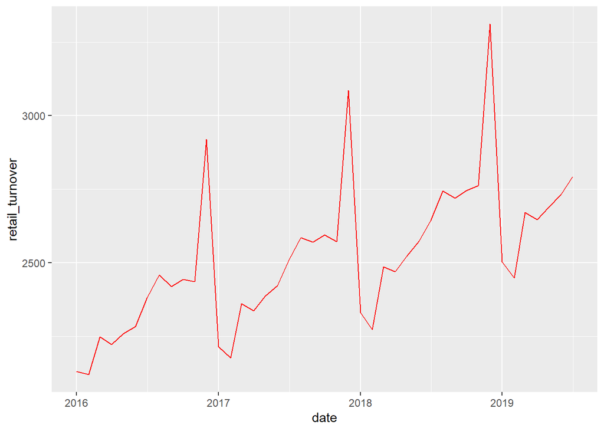

```r
#adding date column
retail <- retail %>% mutate(date = make_date(year, month, day = 1))

ggplot(retail, aes(x = date, y = retail_turnover)) +
  geom_line(color = 'red')
```

Let’s try to model the time series using regression. We can clearly see, that the data is seasonal, so we include both `index` variable to model the trend and `month` variable to model seasonality.

```r
m1 <- lm(retail_turnover ~ index + month, data = retail)
summary(m1)
```

```
##
## Call:
## lm(formula = retail_turnover ~ index + month, data = retail)
##
## Residuals:
##     Min      1Q  Median      3Q     Max
## -182.47  -58.54  -12.40   24.52  359.10
##
## Coefficients:
##             Estimate Std. Error t value Pr(>|t|)
## (Intercept) 1977.020     43.043  45.932  < 2e-16 ***
## index         11.754      1.323   8.882 5.25e-11 ***
## month         46.029      4.847   9.497 8.38e-12 ***
## ---
## Signif. codes:  0 '***' 0.001 '**' 0.01 '*' 0.05 '.' 0.1 ' ' 1
##
## Residual standard error: 107.4 on 40 degrees of freedom
## Multiple R-squared:  0.821,  Adjusted R-squared:  0.812
## F-statistic: 91.73 on 2 and 40 DF,  p-value: 1.141e-15
```

Let’s plot the fitted values.

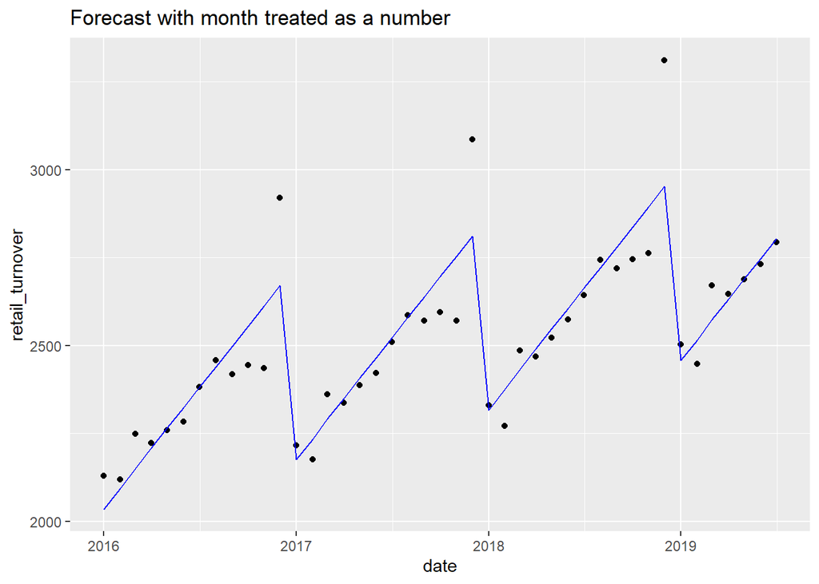

```r
retail %>% add_predictions(m1) %>%
  ggplot(aes(x = date)) +
  geom_point(aes(y = retail_turnover)) +
  geom_line(aes(y = pred), color = 'blue') +
  labs(title = 'Forecast with month treated as a number')
```

The result looks very strange.

The problem is, `month` was treated as a numerical variable. The estimated coefficient for month:

```r
coef(m1)
```

```
## (Intercept)       index       month
##  1977.02015    11.75378    46.02886
```

means, that for January (`month = 1`) we must add 46 to the trend, and for December (`month = 12`) we should add 552. Thus, we are assuming, that sales in December must be 12 times larger than in January. This is clearly wrong.

The correct way of dealing with `month` was to treat is as a categorical variable and to use a factor to correctly model it.

```r
retail <-
  retail %>%
  mutate(monthf = factor(month, labels = c('Jan', 'Feb', 'Mar', 'Apr', 'May', 'Jun', 'Jul', 'Aug', 'Sep', 'Oct', 'Nov', 'Dec')))
```

Now, we’ve added a factor variable with 12 levels:

```r
str(retail)
```

```
## Classes 'spec_tbl_df', 'tbl_df', 'tbl' and 'data.frame': 43 obs. of  6 variables:
##  $ index          : num  1 2 3 4 5 6 7 8 9 10 ...
##  $ year           : num  2016 2016 2016 2016 2016 ...
##  $ month          : num  1 2 3 4 5 6 7 8 9 10 ...
##  $ retail_turnover: num  2130 2119 2248 2223 2258 ...
##  $ date           : Date, format: "2016-01-01" "2016-02-01" ...
##  $ monthf         : Factor w/ 12 levels "Jan","Feb","Mar",..: 1 2 3 4 5 6 7 8 9 10 ...
```

```r
levels(retail$monthf)
```

```
##  [1] "Jan" "Feb" "Mar" "Apr" "May" "Jun" "Jul" "Aug" "Sep" "Oct" "Nov"
## [12] "Dec"
```

Let’s build a model using the new factor variable for months.

```r
m2 <- lm(retail_turnover ~ index + monthf, data = retail)

summary(m2)
```

```
##
## Call:
## lm(formula = retail_turnover ~ index + monthf, data = retail)
##
## Residuals:
##     Min      1Q  Median      3Q     Max
## -52.162 -11.163  -1.963  10.076  75.487
##
## Coefficients:
##              Estimate Std. Error t value Pr(>|t|)
## (Intercept) 2072.3780    15.8377 130.851  < 2e-16 ***
## index         11.6854     0.3558  32.839  < 2e-16 ***
## monthfFeb    -52.2354    20.2577  -2.579 0.015072 *
## monthfMar    123.6293    20.2671   6.100 1.05e-06 ***
## monthfApr     89.1939    20.2827   4.398 0.000127 ***
## monthfMay    122.8335    20.3045   6.050 1.21e-06 ***
## monthfJun    149.4231    20.3326   7.349 3.47e-08 ***
## monthfJul    217.4628    20.3668  10.677 9.73e-12 ***
## monthfAug    289.8813    21.8803  13.248 4.53e-14 ***
## monthfSep    251.3959    21.8890  11.485 1.66e-12 ***
## monthfOct    264.7772    21.9035  12.088 4.64e-13 ***
## monthfNov    248.6919    21.9237  11.344 2.25e-12 ***
## monthfDec    752.8065    21.9497  34.297  < 2e-16 ***
## ---
## Signif. codes:  0 '***' 0.001 '**' 0.01 '*' 0.05 '.' 0.1 ' ' 1
##
## Residual standard error: 28.64 on 30 degrees of freedom
## Multiple R-squared:  0.9904, Adjusted R-squared:  0.9866
## F-statistic: 259.1 on 12 and 30 DF,  p-value: < 2.2e-16
```

Now the model has 12 coefficients - one for index, and 12 - 1 = 11 - for months. The months are treated as separate categories, and the coefficient for a month shows its average difference from the baseline month, which is January (this was the first factor level).

Let’s compare the forecast from the second model:

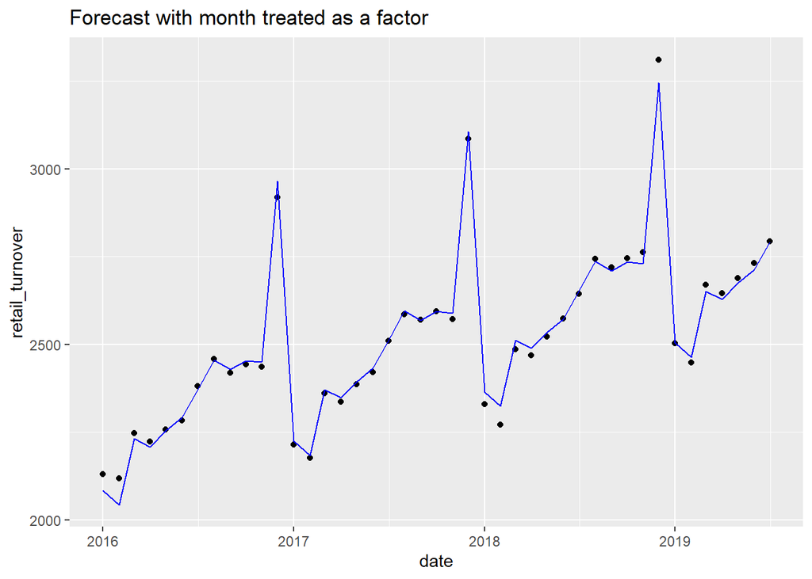

```r
retail %>% add_predictions(m2) %>%
  ggplot(aes(x = date)) +
  geom_point(aes(y = retail_turnover)) +
  geom_line(aes(y = pred), color = 'blue') +
  labs(title = 'Forecast with month treated as a factor')
```

This looks much better.

We could improve the model further, by transforming the output variable. The series shows multiplicative seasonality, but the contribution of each month is constant and the model is additive as a result.

```r
m3 <-
  retail %>%
  mutate(log_retail_turnover = log(retail_turnover)) %>%
  lm(log_retail_turnover ~ index + monthf, data = .)

summary(m3)
```

```
##
## Call:
## lm(formula = log_retail_turnover ~ index + monthf, data = .)
##
## Residuals:
##        Min         1Q     Median         3Q        Max
## -0.0186585 -0.0041077 -0.0008701  0.0032253  0.0240850
##
## Coefficients:
##               Estimate Std. Error  t value Pr(>|t|)
## (Intercept)  7.6474305  0.0044898 1703.276  < 2e-16 ***
## index        0.0046822  0.0001009   46.415  < 2e-16 ***
## monthfFeb   -0.0221802  0.0057429   -3.862 0.000557 ***
## monthfMar    0.0525274  0.0057455    9.142 3.54e-10 ***
## monthfApr    0.0384142  0.0057499    6.681 2.12e-07 ***
## monthfMay    0.0523078  0.0057561    9.087 4.05e-10 ***
## monthfJun    0.0629081  0.0057641   10.914 5.75e-12 ***
## monthfJul    0.0900667  0.0057738   15.599 6.16e-16 ***
## monthfAug    0.1196305  0.0062029   19.286  < 2e-16 ***
## monthfSep    0.1044381  0.0062053   16.830  < 2e-16 ***
## monthfOct    0.1094841  0.0062094   17.632  < 2e-16 ***
## monthfNov    0.1028918  0.0062151   16.555  < 2e-16 ***
## monthfDec    0.2798387  0.0062225   44.972  < 2e-16 ***
## ---
## Signif. codes:  0 '***' 0.001 '**' 0.01 '*' 0.05 '.' 0.1 ' ' 1
##
## Residual standard error: 0.00812 on 30 degrees of freedom
## Multiple R-squared:  0.9949, Adjusted R-squared:  0.9928
## F-statistic:   483 on 12 and 30 DF,  p-value: < 2.2e-16
```

To get predictions on the original scale, we must back-transform the predicted values:

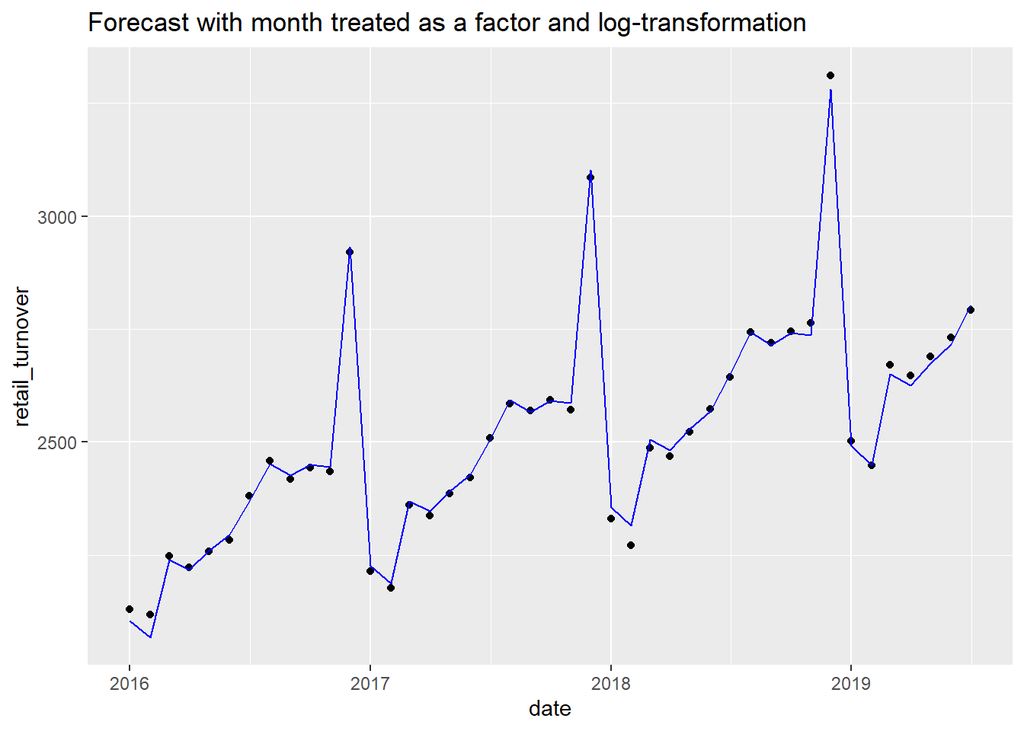

```r
retail %>%
  add_predictions(m3, var = 'log_pred') %>%
  mutate(pred = exp(log_pred)) %>%
  ggplot(aes(x = date)) +
  geom_point(aes(y = retail_turnover)) +
  geom_line(aes(y = pred), color = 'blue') +
  labs(title = 'Forecast with month treated as a factor and log-transformation')
```

Note how December peaks have now different height. Our model can capture now the multiplicative character of the retail sales.